# Pretty tables with {gt}.

Bitcoin

gt

ggplot

bitmexr

R

Traditionally I have been an ardent user of kable + kableExtra when it comes to creating tables. These packages have served me well, however the CRAN release of a new player in the table package space - gt - promted me to try it out and explore some of the features it had to offer.

Published

05/02/2020

`gt` (Iannone, Cheng, and Schloerke 2020) has been under development for a while, but a stable version has recently been released to CRAN. In order to try the package out we first need some data for creating tables. I’ll be using some Bitcoin price data (shameless self plug for my `bitmexr` (Fisher 2020) package that has just landed on CRAN - check it out [here](https://cran.r-project.org/web/packages/bitmexr/index.html)).

For demonstration purposes, I pulled the OHLC prices for the last 10 days.

```r
bitcoin <- bucket_trades(
  binSize = "1d",
  startTime = "2020-04-23",
  endTime = "2020-05-02"
) %>%
  select(1:8) %>%
  select(-symbol)


head(bitcoin)
```

```
   timestamp   open   high    low  close trades     volume
1 2020-04-23 6848.5 7189.0 6822.0 7133.5 572398 1450803027
2 2020-04-24 7133.5 7802.0 7023.5 7492.0 935125 2488032747
3 2020-04-25 7492.0 7610.0 7380.0 7503.5 621057 1473830307
4 2020-04-26 7503.5 7745.0 7431.0 7542.0 641738 1362595381
5 2020-04-27 7542.0 7720.0 7450.0 7702.5 674889 1432590477
6 2020-04-28 7702.5 7836.5 7625.0 7788.0 811266 1663495897
```

The most basic table without any formatting applied looks like this:

```r
bitcoin %>%
  gt()
```

| timestamp | open | high | low | close | trades | volume |
| --- | --- | --- | --- | --- | --- | --- |
| 2020-04-23 | 6848.5 | 7189.0 | 6822.0 | 7133.5 | 572398 | 1450803027 |
| 2020-04-24 | 7133.5 | 7802.0 | 7023.5 | 7492.0 | 935125 | 2488032747 |
| 2020-04-25 | 7492.0 | 7610.0 | 7380.0 | 7503.5 | 621057 | 1473830307 |
| 2020-04-26 | 7503.5 | 7745.0 | 7431.0 | 7542.0 | 641738 | 1362595381 |
| 2020-04-27 | 7542.0 | 7720.0 | 7450.0 | 7702.5 | 674889 | 1432590477 |
| 2020-04-28 | 7702.5 | 7836.5 | 7625.0 | 7788.0 | 811266 | 1663495897 |
| 2020-04-29 | 7788.0 | 7795.5 | 7651.0 | 7752.0 | 520240 | 1154456663 |
| 2020-04-30 | 7752.0 | 8978.0 | 7706.0 | 8794.0 | 2384499 | 5110631297 |
| 2020-05-01 | 8794.0 | 9481.0 | 8407.0 | 8627.5 | 3661752 | 5794365072 |
| 2020-05-02 | 8627.5 | 9065.0 | 8622.5 | 8832.0 | 2085264 | 2573647732 |

To get started, I borrowed some ideas straight from an example on https://gt.rstudio.com/ and applied some simple formatting to the raw data in the table.

- Added a header containing the title and subtitle of the table
- Format the price columns with the appropriate currency symbol
- Format the date column
- Format the trades and volume column with appropriate suffixes

```r
start_date <- format(min(bitcoin$timestamp), "%d/%m/%Y")
end_date <- format(max(bitcoin$timestamp), "%d/%m/%Y")

tab <- bitcoin %>%
  mutate(timestamp = as.character(timestamp)) %>%
  gt() %>%
  tab_header(
    title = md("**Bitcoin price**"),
    subtitle = glue::glue("{start_date} to {end_date}")
  ) %>%
  fmt_currency(
    columns = vars(open, high, low, close),
    currency = "USD"
  ) %>%
  fmt_number(
    columns = vars(trades, volume),
    suffixing = TRUE
  ) %>%
  fmt_date(
    columns = vars(timestamp),
    date_style = 9
  )
tab
```

**Bitcoin price**

23/04/2020 to 02/05/2020

| timestamp | open | high | low | close | trades | volume |
| --- | --- | --- | --- | --- | --- | --- |
| 23 April | $6,848.50 | $7,189.00 | $6,822.00 | $7,133.50 | 572.40K | 1.45B |
| 24 April | $7,133.50 | $7,802.00 | $7,023.50 | $7,492.00 | 935.12K | 2.49B |
| 25 April | $7,492.00 | $7,610.00 | $7,380.00 | $7,503.50 | 621.06K | 1.47B |
| 26 April | $7,503.50 | $7,745.00 | $7,431.00 | $7,542.00 | 641.74K | 1.36B |
| 27 April | $7,542.00 | $7,720.00 | $7,450.00 | $7,702.50 | 674.89K | 1.43B |
| 28 April | $7,702.50 | $7,836.50 | $7,625.00 | $7,788.00 | 811.27K | 1.66B |
| 29 April | $7,788.00 | $7,795.50 | $7,651.00 | $7,752.00 | 520.24K | 1.15B |
| 30 April | $7,752.00 | $8,978.00 | $7,706.00 | $8,794.00 | 2.38M | 5.11B |
| 1 May | $8,794.00 | $9,481.00 | $8,407.00 | $8,627.50 | 3.66M | 5.79B |
| 2 May | $8,627.50 | $9,065.00 | $8,622.50 | $8,832.00 | 2.09M | 2.57B |

Starting to look a little more presentable. Next, I

- Added some colour to highlight changes in the trades and volume columns
- Applied some formatting to the column names.
- I also changed the number of decimal places to 0 (2 decimal places seemd overkill for this example).

A cool feature of `gt` is that you can rename the column labels to something different, but refer to the original labels for any further manipulation.

```r
tab <- tab %>%
  tab_spanner(
    label = "Price",
    columns = vars(open, high, low, close)
  ) %>%
  data_color(
    columns = vars(trades, volume),
    colors = scales::col_numeric("Greens", domain = NULL)
  ) %>%
  cols_align(
    align = "center",
    columns = vars(trades, volume)
  ) %>%
  cols_label(
    timestamp = "Date",
    open = md("**Open**"),
    high = "High",
    low = "Low",
    close = md("**Close**"),
    trades = "Trades",
    volume = "Volume"
  ) %>%
  fmt_currency(
    columns = vars(open, high, low, close),
    currency = "USD",
    decimals = 0
  )
tab
```

**Bitcoin price**

23/04/2020 to 02/05/2020

| Date | Price **Open** | Price High | Price Low | Price **Close** | Trades | Volume |  |  |
| --- | --- | --- | --- | --- | --- | --- | --- | --- |
| 23 April | $6,848 | $7,189 | $6,822 | $7,134 |  |  | 572.40K | 1.45B |
| 24 April | $7,134 | $7,802 | $7,024 | $7,492 | 935.12K | 2.49B |  |  |
| 25 April | $7,492 | $7,610 | $7,380 | $7,504 | 621.06K | 1.47B |  |  |
| 26 April | $7,504 | $7,745 | $7,431 | $7,542 | 641.74K | 1.36B |  |  |
| 27 April | $7,542 | $7,720 | $7,450 | $7,702 | 674.89K | 1.43B |  |  |
| 28 April | $7,702 | $7,836 | $7,625 | $7,788 | 811.27K | 1.66B |  |  |
| 29 April | $7,788 | $7,796 | $7,651 | $7,752 | 520.24K | 1.15B |  |  |
| 30 April | $7,752 | $8,978 | $7,706 | $8,794 | 2.38M | 5.11B |  |  |
| 1 May | $8,794 | $9,481 | $8,407 | $8,628 | 3.66M | 5.79B |  |  |
| 2 May | $8,628 | $9,065 | $8,622 | $8,832 | 2.09M | 2.57B |  |  |

```r
rocket <- "<span style=\"color:green\">&#128640;</span>"
sadface <- "<span style=\"color:red\">&#128546;</span>"

tab <- tab %>%
  text_transform(
    locations = cells_body(
      columns = "close",
      rows = close > open
    ),
    fn = function(x) paste(x, rocket)
  ) %>%
  text_transform(
    locations = cells_body(
      columns = "close",
      rows = close < open
    ),
    fn = function(x) paste(x, sadface)
  )

tab
```

**Bitcoin price**

23/04/2020 to 02/05/2020

| Date | Price **Open** | Price High | Price Low | Price **Close** | Trades | Volume |  |  |
| --- | --- | --- | --- | --- | --- | --- | --- | --- |
| 23 April | $6,848 | $7,189 | $6,822 | $7,134 🚀 |  |  | 572.40K | 1.45B |
| 24 April | $7,134 | $7,802 | $7,024 | $7,492 🚀 | 935.12K | 2.49B |  |  |
| 25 April | $7,492 | $7,610 | $7,380 | $7,504 🚀 | 621.06K | 1.47B |  |  |
| 26 April | $7,504 | $7,745 | $7,431 | $7,542 🚀 | 641.74K | 1.36B |  |  |
| 27 April | $7,542 | $7,720 | $7,450 | $7,702 🚀 | 674.89K | 1.43B |  |  |
| 28 April | $7,702 | $7,836 | $7,625 | $7,788 🚀 | 811.27K | 1.66B |  |  |
| 29 April | $7,788 | $7,796 | $7,651 | $7,752 😢 | 520.24K | 1.15B |  |  |
| 30 April | $7,752 | $8,978 | $7,706 | $8,794 🚀 | 2.38M | 5.11B |  |  |
| 1 May | $8,794 | $9,481 | $8,407 | $8,628 😢 | 3.66M | 5.79B |  |  |
| 2 May | $8,628 | $9,065 | $8,622 | $8,832 🚀 | 2.09M | 2.57B |  |  |

Looks good! I’ve barely scratched the surface of what `gt` can do here and the [package website](https://gt.rstudio.com/) is well worth a look if you are interested.

## Bonus table

One experimental feature in `gt` is the ability to add a ggplot (or any image for that matter) to a table. Yes thats right, a ggplot in a table. I did have to do a bit of rummaging in the package repo to get this to work, but the idea is really cool.

First I define a few functions that will help in creating the table/plot combo.

```r
# helper for summary data
oc <- function(name, df) {
  df %>%
    summarise(
      open = dplyr::first(open),
      close = dplyr::last(close),
      volume = sum(volume),
      trades = sum(trades),
      date = dplyr::first(timestamp)
    )
}

# ggplot for each week
plot_group <- function(name, df) {
  plot_object <-
    ggplot(
      data = df,
      aes(x = timestamp, y = close)
    ) +
    geom_barchart(
      aes(open = open, high = high, low = low, close = close),
      fill_up = "green",
      fill_down = "red",
      colour_up = "green",
      colour_down = "red"
    ) +
    theme_minimal() +
    theme(
      legend.position = "none",
      axis.title = element_blank(),
      axis.text = element_blank()
    )
  return(plot_object)
}

# combine ggplot within table
fmt_ggplot <- fmt_gg <- function(
  data,
  columns,
  rows = NULL,
  height = 100,
  aspect_ratio = 1.0
) {
  rows <- rlang::enquo(rows)

  fmt(
    data = data,
    columns = columns,
    rows = !!rows,
    fns = list(
      html = function(x) {
        map(
          x,
          ggplot_image,
          height = height,
          aspect_ratio = aspect_ratio
        )
      }
    )
  )
}
```

1. The first is just a simple helper function which generates some summary information for the final table
2. The second is the ggplot object that will be used to visualise each weeks data.
3. The third was borrowed straight from gt’s repo [here](https://github.com/rstudio/gt/pull/155/commits/fb862bdd16a8c7236727e51ddeff700cd2540b75). I think some of this functionality is still under development, so is not yet available in the CRAN release.

2022 update: It is now much easier to support ggplot objects in gt tables! See [here](https://gt.rstudio.com/reference/ggplot_image.html)

We’re now ready to prepare the data for the table.

```r
newdata <- map_bucket_trades(
  start_date = "2020-04-01",
  end_date = "2020-04-28",
  binSize = "1h"
) %>%
  mutate(week = lubridate::week(timestamp)) %>%
  select(week, timestamp, open, high, low, close, volume, trades) %>%
  group_by(week) %>%
  nest() %>%
  mutate(
    plot = map2(week, data, plot_group),
    info = map2(week, data, oc)
  ) %>%
  unnest(info)

head(newdata)
```

```
# A tibble: 4 × 8
# Groups:   week [4]
   week data               plot    open close  volume trades date
  <dbl> <list>             <list> <dbl> <dbl>   <dbl>  <int> <dttm>
1    14 <tibble [168 × 7]> <gg>   6440. 7166  1.45e10 5.35e6 2020-04-01 00:00:00
2    15 <tibble [168 × 7]> <gg>   7166  6880. 1.21e10 4.67e6 2020-04-08 00:00:00
3    16 <tibble [168 × 7]> <gg>   6880. 6898. 1.20e10 4.24e6 2020-04-15 00:00:00
4    17 <tibble [145 × 7]> <gg>   6898. 7788  9.93e 9 4.28e6 2020-04-22 00:00:00
```

Now the data is ready, we can make the table.

**Price action summary for April 2020**

Week beginning

Summary

Price action

Volume

Trades

Open

Close

1 April 2020

14.53B

5.35M

$6,440.50

$7,166.00

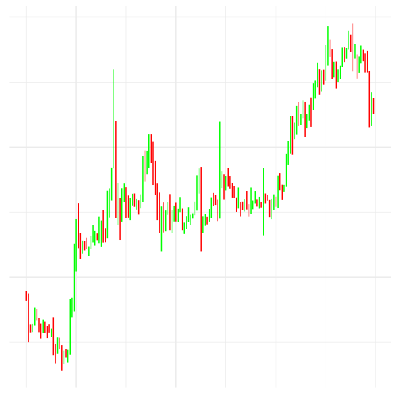

8 April 2020

12.10B

4.67M

$7,166.00

$6,880.50

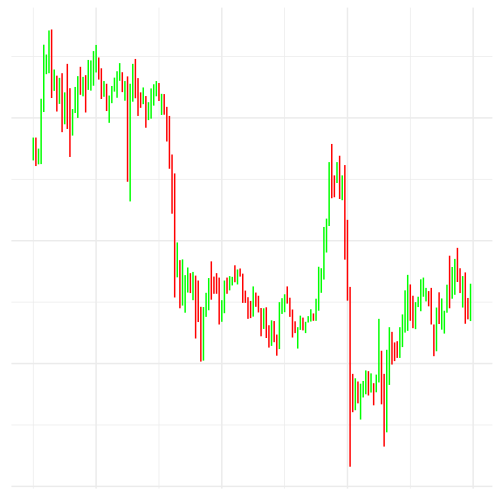

15 April 2020

12.03B

4.24M

$6,880.50

$6,897.50

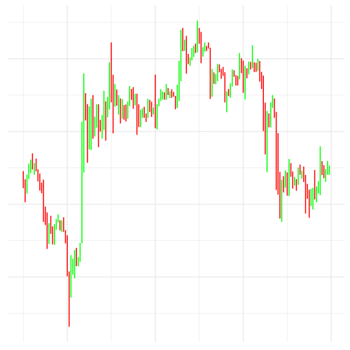

22 April 2020

9.93B

4.28M

$6,897.50

$7,788.00

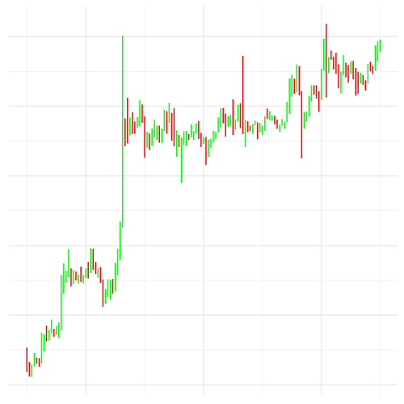

```r
newdata %>%
  ungroup() %>%
  select(date, volume, trades, open, close, plot) %>%
  mutate(date = as.character(date)) %>%
  gt() %>%
  text_transform(
    locations = cells_body(columns = plot),
    fn = function(x) {
      newdata$plot %>%
        ggplot_image(height = px(200))
    }
  ) %>%
  fmt_number(
    columns = c(trades, volume),
    suffixing = TRUE
  ) %>%
  fmt_date(
    columns = c(date),
    date_style = 8
  ) %>%
  cols_align(
    align = "center"
  ) %>%
  fmt_currency(
    columns = c(open, close)
  ) %>%
  tab_header(
    title = md("**Price action summary for April 2020**")
  ) %>%
  cols_label(
    date = "Week beginning",
    open = "Open",
    close = "Close",
    trades = "Trades",
    volume = "Volume",
    plot = "Price action"
  ) %>%
  tab_spanner(
    label = "Summary",
    columns = c(volume, trades, open, close)
  )
```

Pretty cool! The possibilities are endless with this and it was good fun trying to get it to work.

## References

Fisher, Harry. 2020. *Bitmexr: R Client for BitMEX*. https://CRAN.R-project.org/package=bitmexr.

Iannone, Richard, Joe Cheng, and Barret Schloerke. 2020. *Gt: Easily Create Presentation-Ready Display Tables*. https://github.com/rstudio/gt.